# White Fragility & Moral Affirmation Study 3

# Initial Paths in the MFM Model

**Defensiveness and Systemic Racism**

No significant association found between the wealth gap article and increased defensiveness.

## Affect and Systemic Racism

**Sadness:** Wealth gap article induces the most sadness.

**Optimism/Pessimism:** No gap condition is most optimistic, while the gap condition is more pessimistic than the control condition.

**Tone Analysis:** Gap condition has the most negative tone, whereas the no gap condition exhibits the most positive tone.

**Sentiment**: Individuals feel worse after reading the gap article, but the no gap article leads to the most positive emotions.

**Specific Emotions (Shame, Guilt, Outrage):** Gap condition induces the highest levels of shame, guilt, and outrage, while the no gap and control conditions yield similar amounts of these emotions.

**Empathy:** No discernible difference in empathy across conditions.

# Self Protective/Reflective Pathways

**Bias-Awareness, Affect, and Defensiveness:**

Moderation Analysis:

- Bias-awareness does not significantly moderate the relationship between affect and article condition.
- It almost moderates the relationship with defensiveness (β = 0.07), indicating that increased bias-awareness is associated with decreased defensiveness.

**Color-Blind Ideology, Affect, and Defensiveness:**

Moderation Analysis:

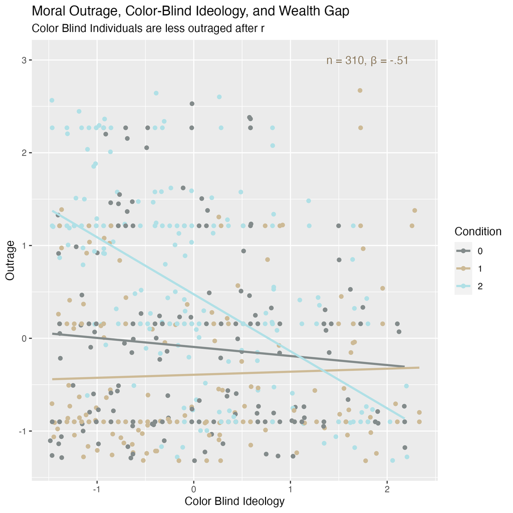

- It also moderates the relationship with defensiveness, indicating that those who endorse color-blind racial ideology respond more defensively to the wealth gap article.

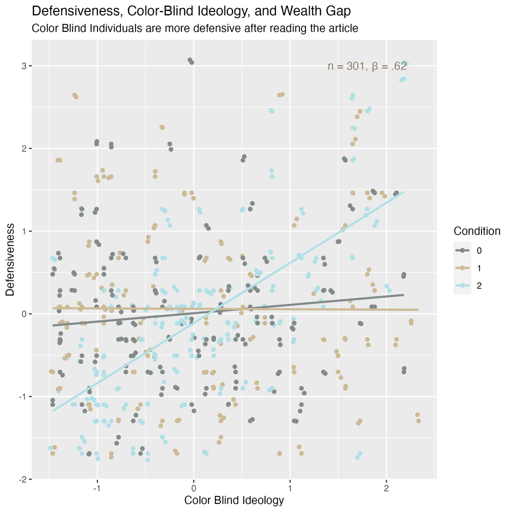

**Collective Narcissism, Affect, and Defensiveness:**

Moderation Analysis:

- Collective Narcissism moderates the relationship between article condition and outrage/sadness, such that those higher in collective narcissism are less likely to report outrage/sadness.
- It does not moderate the relationship with defensiveness.

**Social Dominance Orientation, Affect, and Defensiveness:**

Moderation Analysis:

- Social Dominance Orientation moderates the relationship between article condition and outrage/sadness/shame/guilt, such that those higher in social dominance orientation are less likely to report these affects.
- It also moderates the relationship with defensiveness, indicating that those who endorse social dominance orientation are less likely to report affect and more likely to respond defensively when reading about the racial wealth gap.

**Racial Centrality, Affect, and Defensiveness:**

Moderation Analysis:

- Racial centrality generally does not moderate any of the relationships.

**Public & Private Regard, Affect, and Defensiveness:**

Public Regard Moderation Analysis:

- People high in public regard felt sadder, more pessimistic, and found the article less promising when reading the racial gap article.
- Public regard did not moderate the relationship between defensiveness or any of the other affective variables.

Private Regard Moderation Analysis:

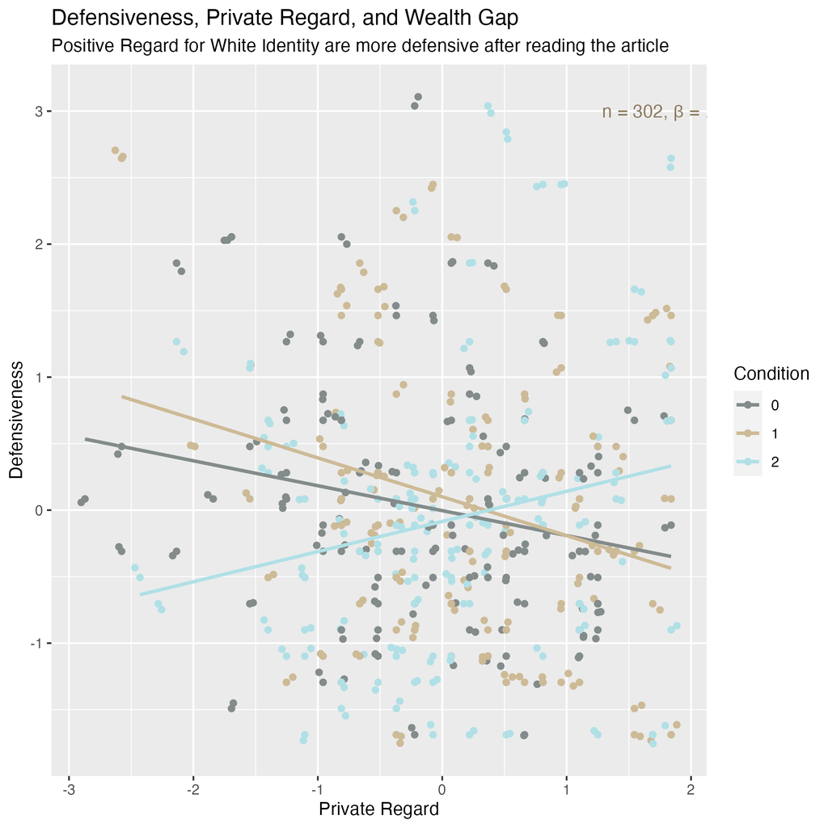

**Public Awareness & Normative Pressure, Affect, and Defensiveness:**

Public Awareness Moderation Analysis:

- People who thought that Americans were generally aware of racial issues felt sadder and found the article more pessimistic.
- Public awareness did not moderate the relationship between defensiveness or any of the other affective variables.

Normative Pressure Moderation Analysis:

- Higher normative pressure to be aware of racial biases leads to more shame when reading about the racial wealth gap.
- Those who feel normative pressure are less defensive and report more shame and guilt when reading about racial inequality.

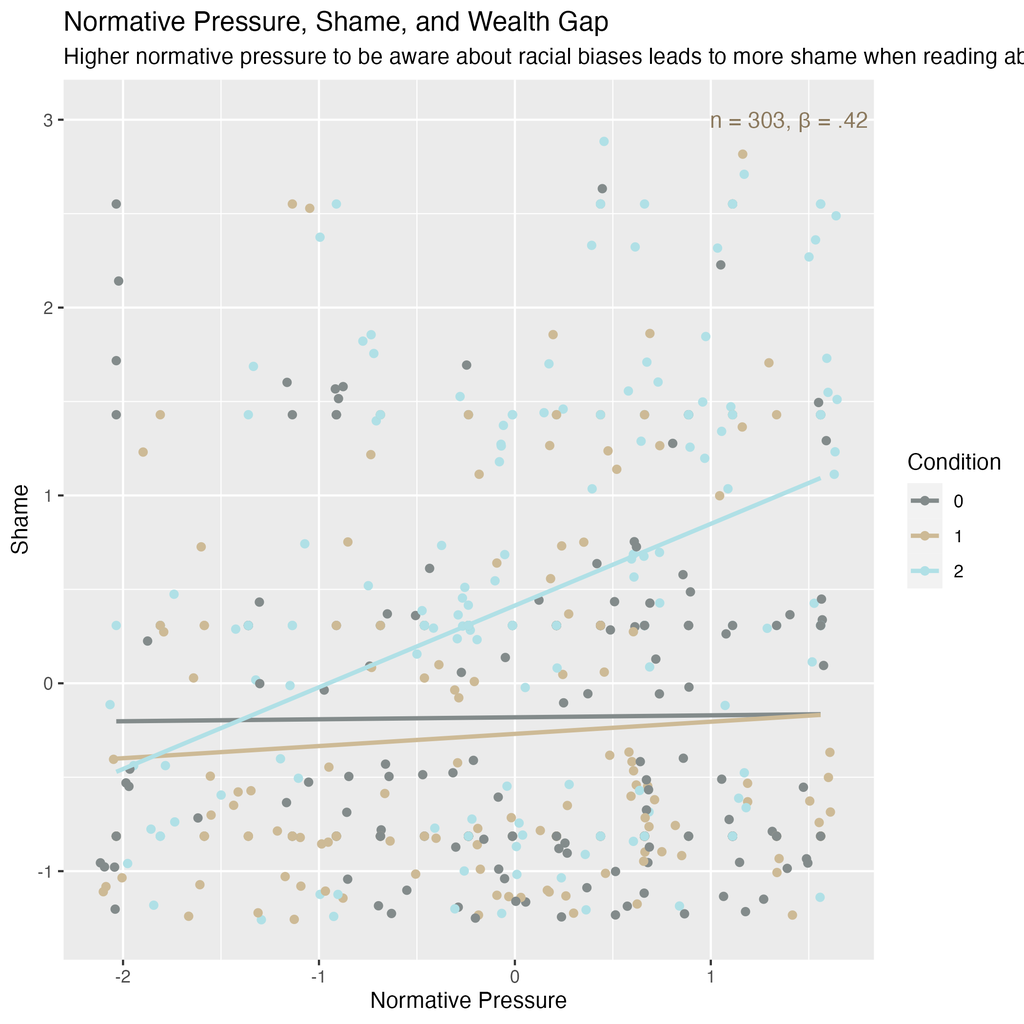

**Discrimination Concern, Affect, and Defensiveness:**

Discrimination Concern Moderation Analysis:

- Discrimination Concern moderates the relationship between all affect variables and article condition.
- Those who consider racial discrimination to be a problem are more likely to report negative affect when reading about the racial inequality gap and less likely to respond defensively.

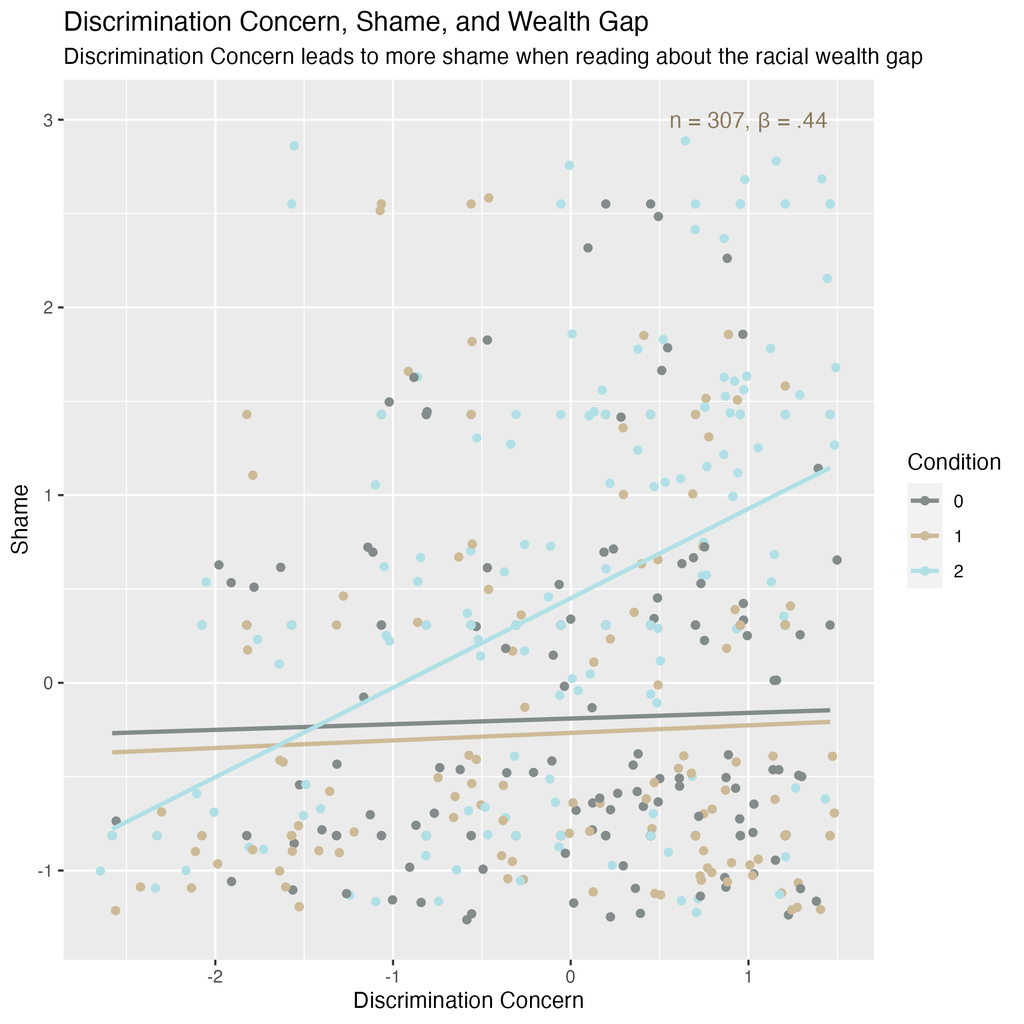

[figure not shown]

**Racial Climate/Interracial Contact, Affect, and Defensiveness:**

Racial Climate Moderation Analysis:

- Racial Climate does not moderate any of the variables.

Interracial Contact Moderation Analysis:

- Interracial contact is associated with lower guilt after reading the article.

# Esteem After reading the Articles

**Personal Self-Esteem:**

- Negative affect (anger, shame, guilt, outrage, article tone/feelings; B = -.15 to -.25) is related to lower personal self-esteem.
- Defensiveness is also associated with lower personal self-esteem, and this effect holds even when controlling for all other variables.

**Public Self-Esteem:**

- Negative affect (anger, shame, guilt, outrage, article tone/feelings; B = -.15 to -.29) is related to lower public collective self-esteem (believing others have a positive image of White Americans).
- Defensiveness is also associated with lower public collective self-esteem, and this effect remains robust even when controlling for all other variables.

**Private Collective Self-Esteem:**

- Negative affect (anger, shame, guilt, outrage, article tone/feelings; B = -.15 to -.25) is related to lower private collective self-esteem (personal self-esteem regarding White Americans).
- Defensiveness is not significantly associated with private collective self-esteem.
- Article condition alone is not a significant predictor of private collective self-esteem.

**Discussion of Self-Revision Findings:**

These results highlight the impact of negative affect and defensiveness on personal self-esteem, public collective self-esteem, and private collective self-esteem after reading the article on racial wealth gap. Negative affect consistently predicts lower self-esteem across these dimensions, suggesting a robust relationship. Defensiveness also plays a role in predicting lower personal and public collective self-esteem, emphasizing its influence in shaping individuals’ perceptions. The article condition alone does not appear to be a significant predictor of collective self-esteem.

*We find evidence for the self-reflective pathway, but not necessarily for the self-protective pathway. We should discuss these findings.*